# R Notebook

This R-markdown entails the analysis i conducted of the data set “Transactions from a bakery” provided by the kaggle user Xavier (https://www.kaggle.com/xvivancos).

The data set is loaded regularly for the Experimental Data Analysis (EDA) and also read in as transaction data using the read.transactions() function from the R-package “arules”.

```r
library(ggplot2)
library(tidyverse)
library(ggpubr)
library(lubridate)
library(arules)
library(arulesViz)
library(knitr)
library(gridExtra)

data <- read.csv("/Users/julianblau/Downloads/BreadBasket_DMS.csv")
transaction.data <- read.transactions("/Users/julianblau/Downloads/BreadBasket_DMS.csv",
                                      format="single", cols=c(3,4), sep=",",
                                      rm.duplicates=TRUE)
```

A quick overview of the data set at hand.

```r
str(data)
```

```
## 'data.frame':    21293 obs. of  4 variables:
##  $ Date       : Factor w/ 159 levels "2016-10-30","2016-10-31",..: 1 1 1 1 1 1 1 1 1 1 ...
##  $ Time       : Factor w/ 8240 levels "01:21:05","07:29:57",..: 1236 1345 1345 1379 1379 1379 1389 1466 1466 1466 ...
##  $ Transaction: int  1 2 2 3 3 3 4 5 5 5 ...
##  $ Item       : Factor w/ 95 levels "Adjustment","Afternoon with the baker",..: 12 76 76 49 50 27 61 24 67 12 ...
```

```r
head(data)
```

|  | Date | Time | Transaction | Item |
| --- | --- | --- | --- | --- |
| 1 | 2016-10-30 | 09:58:11 | 1 | Bread |
| 2 | 2016-10-30 | 10:05:34 | 2 | Scandinavian |
| 3 | 2016-10-30 | 10:05:34 | 2 | Scandinavian |
| 4 | 2016-10-30 | 10:07:57 | 3 | Hot chocolate |
| 5 | 2016-10-30 | 10:07:57 | 3 | Jam |
| 6 | 2016-10-30 | 10:07:57 | 3 | Cookies |

Converting the “Date” and “Time” formats for further analysis.

```r
data <- data %>%
  mutate(
    Date = as.Date(Date),
    Time = hms(Time)
  )

data$Weekdays <- weekdays(data$Date)
```

Analyzing most frequently purchased products.

```r
data.items <- data %>% group_by(Item) %>% summarise(count=n())
data.items <- data.items[order(-data.items$count),]
data.items
```

| Item | count |
| --- | --- |
| Coffee | 5471 |
| Bread | 3325 |
| Tea | 1435 |
| Cake | 1025 |
| Pastry | 856 |
| NONE | 786 |
| Sandwich | 771 |
| Medialuna | 616 |
| Hot chocolate | 590 |
| Cookies | 540 |

[output cut: 85 more lines]

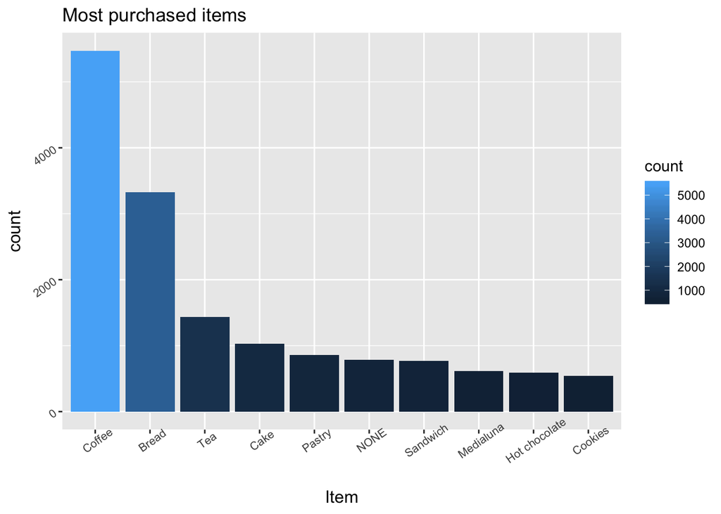

```r
ggplot(data.items[1:10,], aes(x = reorder(Item, -count),
                              y = count, fill=count))+
  geom_bar(stat = "identity")+
  labs(title="Most purchased items", x="Item",
       y="count")+
  theme(axis.title = element_text(size=12),
        axis.text=element_text(size=8, angle = 35))
```

Coffee is the most purchased item at the bakery, followed by bread, tea and other products. The item “NONE” is unknown but will not be excluded as the information will be updated once clarified in the kaggle discussion thread.

A quick look at the items sold at the bakery. Here the item “Adjustment” appears, which seems to be some input from the cashier machine.

```r
items <- unique(data$Item)
items <- sort(items, decreasing = F)
head(items)
```

```
## [1] Adjustment               Afternoon with the baker
## [3] Alfajores                Argentina Night
## [5] Art Tray                 Bacon
## 95 Levels: Adjustment Afternoon with the baker ... Victorian Sponge
```

Analysis of the transactions per month.

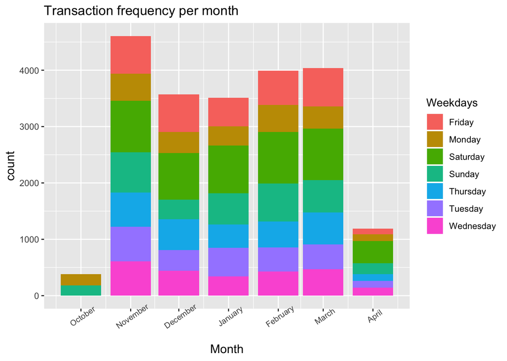

```r
data.days <- data %>% group_by(Date) %>% summarise(count=n())
data.days$month <- as.Date(cut(data.days$Date, breaks = "month"))
data.days$Weekdays <- weekdays(data.days$Date)

ggplot(data.days, aes(month, count, fill=Weekdays))+
  geom_bar(stat = "identity")+
  scale_x_date(date_labels = "%B", date_breaks = "1 month")+
  labs(title="Transaction frequency per month", x="Month")+
  theme(axis.title = element_text(size=12),
        axis.text.x=element_text(size=8, angle = 35))
```

October falls short as the data collected is of the 30th of the month and April only includes the first 9 days. This said, November seems to be the month with the most transactions followed by March and February.

Taking a closer look at the transaction distribution for each weekday, it becomes clear that Saturdays are the highest turnover days. The top 10 days by accumulated transactions are all Saturdays.

```r
data.days.desc <- data.days[order(-data.days$count), ]
data.days.desc
```

| Date | count | month | Weekdays |
| --- | --- | --- | --- |
| 2017-02-04 | 302 | 2017-02-01 | Saturday |
| 2016-11-05 | 283 | 2016-11-01 | Saturday |
| 2017-03-04 | 265 | 2017-03-01 | Saturday |
| 2017-03-25 | 254 | 2017-03-01 | Saturday |
| 2017-01-28 | 243 | 2017-01-01 | Saturday |
| 2017-02-18 | 240 | 2017-02-01 | Saturday |
| 2016-11-12 | 227 | 2016-11-01 | Saturday |
| 2016-11-19 | 216 | 2016-11-01 | Saturday |
| 2017-03-11 | 210 | 2017-03-01 | Saturday |
| 2017-04-08 | 209 | 2017-04-01 | Saturday |

[output cut: 149 more lines]

```r
data.weekday.rev <- aggregate(data.days.desc$count, by=list(Category=data.days.desc$Weekdays), FUN=sum)
data.weekday.rev <- data.weekday.rev[order(-data.weekday.rev$x), ]
data.weekday.rev
```

|  | Category | x |
| --- | --- | --- |
| 3 | Saturday | 4803 |
| 1 | Friday | 3235 |
| 4 | Sunday | 3233 |
| 5 | Thursday | 2719 |
| 6 | Tuesday | 2480 |
| 7 | Wednesday | 2429 |
| 2 | Monday | 2394 |

```r
data.weekday.rev$percent <- (prop.table(data.weekday.rev$x)*100)
data.weekday.rev
```

|  | Category | x | percent |
| --- | --- | --- | --- |
| 3 | Saturday | 4803 | 22.55671 |
| 1 | Friday | 3235 | 15.19279 |
| 4 | Sunday | 3233 | 15.18339 |
| 5 | Thursday | 2719 | 12.76945 |
| 6 | Tuesday | 2480 | 11.64702 |
| 7 | Wednesday | 2429 | 11.40750 |
| 2 | Monday | 2394 | 11.24313 |

To ensure that these percentages aren’t falsified by a more Saturdays then other days in the data set, the weekdays are summed up.

```r
sales.days <- unique(data$Date)
sales.days <- as.data.frame(sales.days)
colnames(sales.days) <- "Date"
sales.days$weekday <- weekdays(as.Date(sales.days$Date))
sales.days
```

| Date | weekday |
| --- | --- |
| 2016-10-30 | Sunday |
| 2016-10-31 | Monday |
| 2016-11-01 | Tuesday |
| 2016-11-02 | Wednesday |
| 2016-11-03 | Thursday |
| 2016-11-04 | Friday |
| 2016-11-05 | Saturday |
| 2016-11-06 | Sunday |
| 2016-11-07 | Monday |
| 2016-11-08 | Tuesday |

[output cut: 149 more lines]

```r
sales.days.sum <- sales.days %>% group_by(weekday) %>% summarise(count=n())
sales.days.sum
```

| weekday | count |
| --- | --- |
| Friday | 23 |
| Monday | 21 |
| Saturday | 23 |
| Sunday | 23 |
| Thursday | 23 |
| Tuesday | 23 |
| Wednesday | 23 |

The amount of weekdays are almost equal, solely Mondays are missing two days.

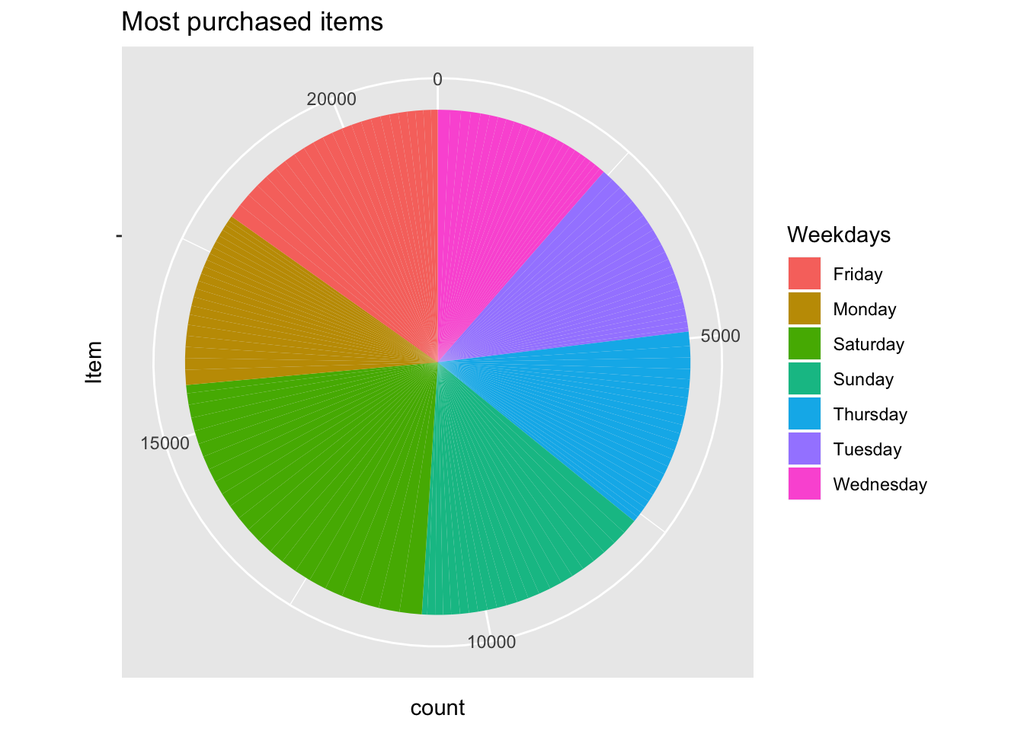

```r
ggplot(data.days.desc, aes(x="", y=count, fill=Weekdays))+
  geom_bar(width = 1, stat = "identity")+
  coord_polar("y", start=0)+
  labs(title="Most purchased items", x="Item",
       y="count")
```

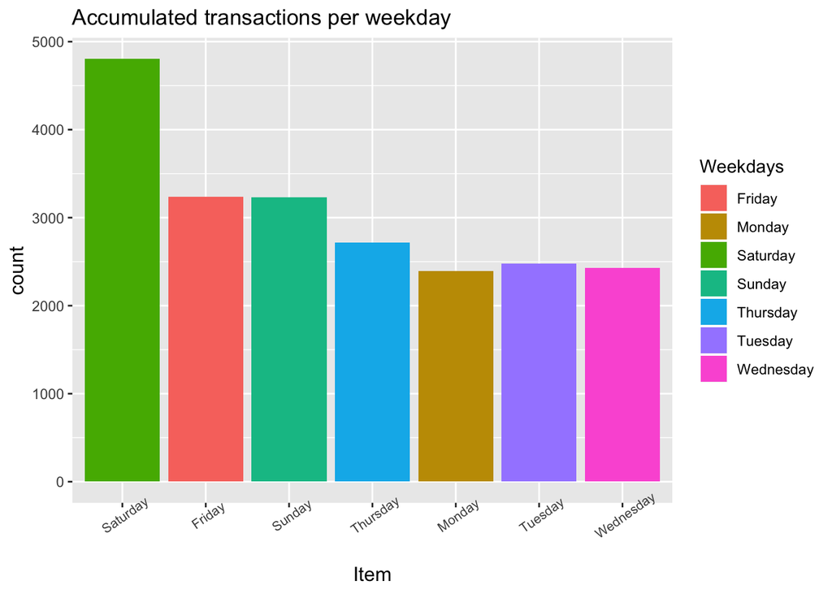

```r
ggplot(data.days.desc, aes(x=reorder(Weekdays, -count), y=count, fill=Weekdays))+
  geom_bar(stat = "identity")+
  labs(title="Accumulated transactions per weekday", x="Item",
       y="count")+
  theme(axis.title = element_text(size=12),
        axis.text.x=element_text(size=8, angle = 35))
```

These two figures visualize the previous findings of Saturday being the day with the most transactions.

As Mondays can get quite rough, coffee can be a life saver. Lets look if Mondays show higher coffee sales then other days.

```r
coffee.sales <- aggregate(data$Item == "Coffee", by=list(Category=data$Weekdays), FUN=sum)
coffee.sales$percent <- (prop.table(coffee.sales$x)*100)
coffee.sales
```

| Category | x | percent |
| --- | --- | --- |
| Friday | 854 | 15.60958 |
| Monday | 681 | 12.44745 |
| Saturday | 1103 | 20.16085 |
| Sunday | 825 | 15.07951 |
| Thursday | 670 | 12.24639 |
| Tuesday | 710 | 12.97752 |
| Wednesday | 628 | 11.47871 |

Surprisingly, the proportions of coffee sales are fairly similar to the overall transaction proportions for the weekdays.

Knowing the time and amount of transaction frequencies can help the bakery management to plan their staff schedule accordingly.

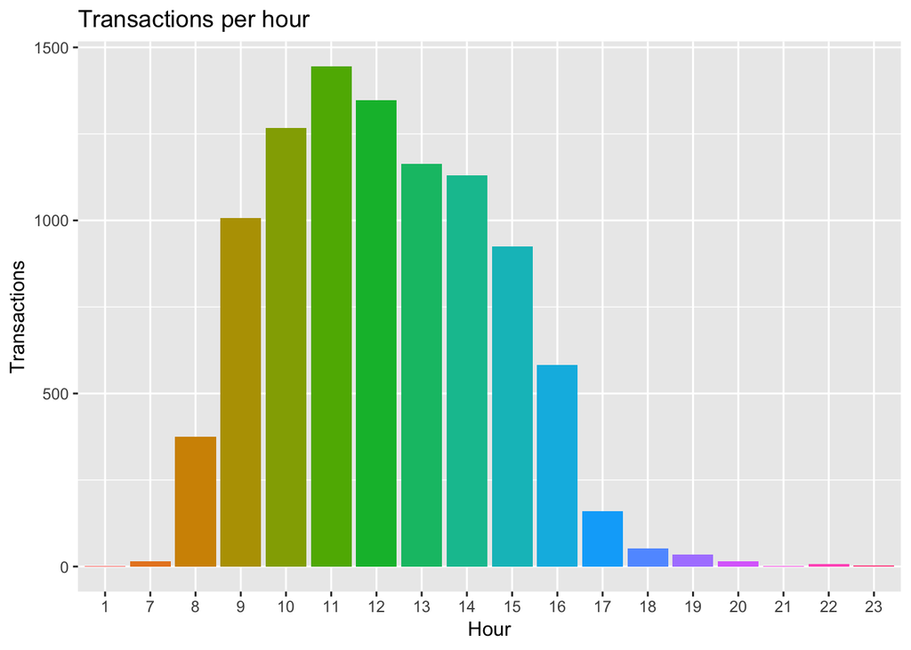

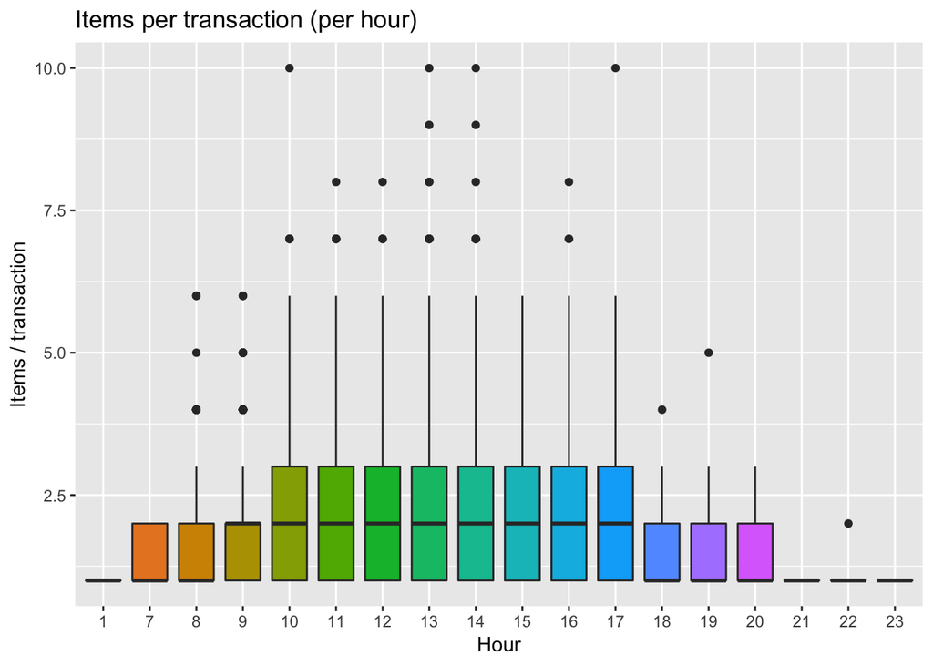

The busiest time for the bakery is between 9 am and 4 pm with a peak around lunch time at 11-12 am. Opening hours seem to be 7 am to 8 pm with exceptions where the bakery was open till 1 am the next day. Might have been a big event.

```r
frequentItems <- eclat(transaction.data, parameter = list(supp=0.07, maxlen=15))
```

```
## Eclat
##
## parameter specification:
##  tidLists support minlen maxlen            target   ext
##     FALSE    0.07      1     15 frequent itemsets FALSE
##
## algorithmic control:
##  sparse sort verbose
##       7   -2    TRUE
##
## Absolute minimum support count: 462
##
## create itemset ...
## set transactions ...[104 item(s), 6614 transaction(s)] done [0.00s].
## sorting and recoding items ... [7 item(s)] done [0.00s].
## creating bit matrix ... [7 row(s), 6614 column(s)] done [0.00s].
## writing  ... [8 set(s)] done [0.00s].
## Creating S4 object  ... done [0.00s].
```

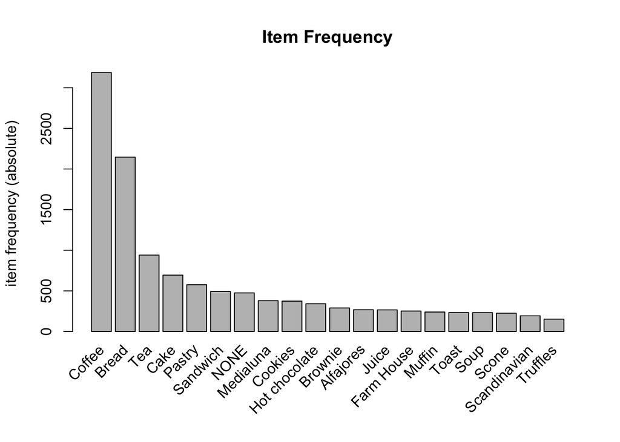

```r
itemFrequencyPlot(transaction.data, topN=20, type="absolute", main= "Item Frequency")
```

Now we will take a look at association rules.

```r
rules <- apriori(transaction.data, parameter = list(supp= 0.001, conf= 0.5))
```

```
## Apriori
##
## Parameter specification:
##  confidence minval smax arem  aval originalSupport maxtime support minlen
##         0.5    0.1    1 none FALSE            TRUE       5   0.001      1
##  maxlen target   ext
##      10  rules FALSE
##
## Algorithmic control:
##  filter tree heap memopt load sort verbose
##     0.1 TRUE TRUE  FALSE TRUE    2    TRUE
##
## Absolute minimum support count: 6
##
## set item appearances ...[0 item(s)] done [0.00s].
## set transactions ...[104 item(s), 6614 transaction(s)] done [0.00s].
## sorting and recoding items ... [60 item(s)] done [0.00s].
## creating transaction tree ... done [0.00s].
## checking subsets of size 1 2 3 4 done [0.00s].
## writing ... [135 rule(s)] done [0.00s].
## creating S4 object  ... done [0.00s].
```

```r
ruleConf <- sort(rules, by="confidence", decreasing = T)

inspect(head(ruleConf))
```

```
##     lhs                               rhs      support     confidence
## [1] {NONE,Tartine}                 => {Coffee} 0.001209555 1.0000000
## [2] {Hot chocolate,Medialuna,NONE} => {Coffee} 0.001209555 1.0000000
## [3] {Cake,Hot chocolate,Sandwich}  => {Coffee} 0.001209555 1.0000000
## [4] {Hearty & Seasonal,Sandwich}   => {Coffee} 0.001360750 0.9000000
## [5] {Pastry,Sandwich}              => {Coffee} 0.001360750 0.9000000
## [6] {Pastry,Toast}                 => {Coffee} 0.001209555 0.8888889
##     lift     count
## [1] 2.074655 8
## [2] 2.074655 8
## [3] 2.074655 8
## [4] 1.867189 9
## [5] 1.867189 9
## [6] 1.844138 8
```

```
## To reduce overplotting, jitter is added! Use jitter = 0 to prevent jitter.
```

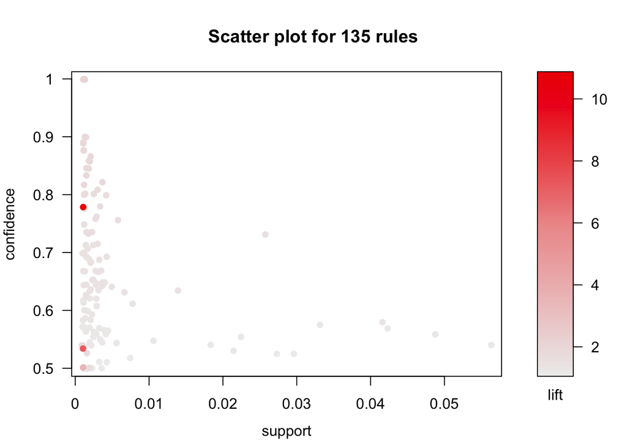

```r
plot(rules)
```

```r
head(quality(rules))
```

|  | support | confidence | lift | count |
| --- | --- | --- | --- | --- |
| 1 | 0.001058361 | 0.7777778 | 1.613621 | 7 |
| 2 | 0.001058361 | 0.7777778 | 10.829942 | 7 |
| 3 | 0.002267917 | 0.6521739 | 1.353036 | 15 |
| 4 | 0.002267917 | 0.6818182 | 1.414537 | 15 |
| 5 | 0.002116722 | 0.5000000 | 1.037327 | 14 |
| 6 | 0.003175083 | 0.6363636 | 1.320235 | 21 |

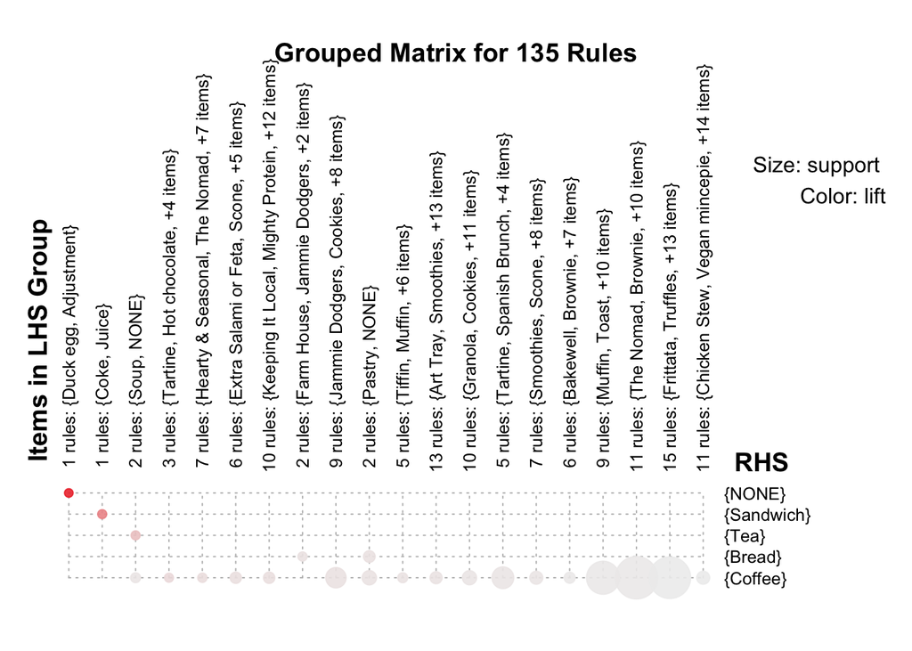

```r
plot(rules, method = "grouped")
```

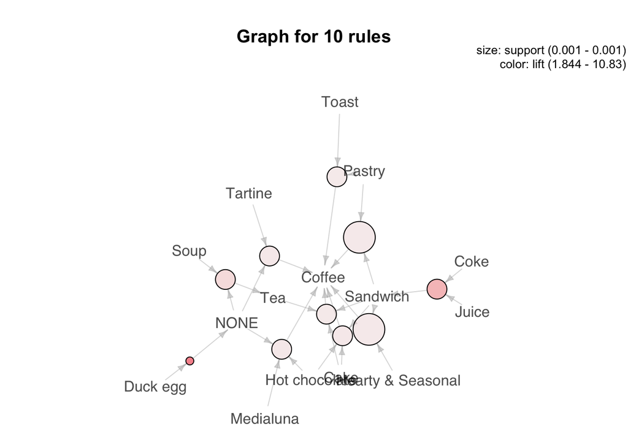

```r
subrules2 <- head(rules, n = 10, by = "lift")

plot(subrules2, method = "graph")
```

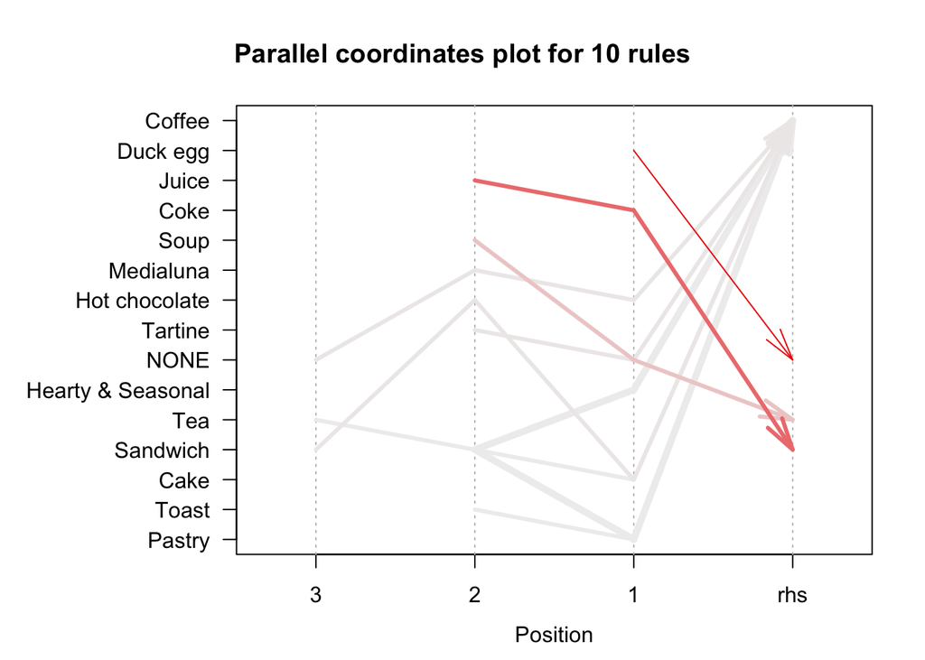

```r
plot(subrules2, method = "paracoord")
```

Lift is the factor by which, the co-occurrence of A and B exceeds the expected probability of A and B co-occurring, had they been independent. So, higher the lift, higher the chance of A and B occurring together.

```r
rulesHighLift <- sort(rules, by="lift", decreasing = T)

inspect(head(rulesHighLift))
```

```
##     lhs                               rhs        support     confidence
## [1] {Duck egg}                     => {NONE}     0.001058361 0.7777778
## [2] {Coke,Juice}                   => {Sandwich} 0.001209555 0.5333333
## [3] {NONE,Soup}                    => {Tea}      0.001209555 0.5000000
## [4] {NONE,Tartine}                 => {Coffee}   0.001209555 1.0000000
## [5] {Hot chocolate,Medialuna,NONE} => {Coffee}   0.001209555 1.0000000
## [6] {Cake,Hot chocolate,Sandwich}  => {Coffee}   0.001209555 1.0000000
##     lift      count
## [1] 10.829942 7
## [2]  7.155105 8
## [3]  3.514346 8
## [4]  2.074655 8
## [5]  2.074655 8
## [6]  2.074655 8
```

Now we will look at products that were purchased after/along with Tea.

```r
rulesItemSpecific <- apriori (transaction.data, parameter=list (supp=0.001,conf = 0.08), appearance = list (default="lhs",rhs="Tea"), control = list (verbose=F))

rulesItemSpecificConf <- sort(rulesItemSpecific, by="confidence", decreasing = T)

inspect(head(rulesItemSpecificConf))
```

```
##     lhs                    rhs   support     confidence lift     count
## [1] {NONE,Soup}         => {Tea} 0.001209555 0.5000000  3.514346  8
## [2] {Cake,Scone}        => {Tea} 0.001965528 0.4193548  2.947516 13
## [3] {Cake,Coffee,Scone} => {Tea} 0.001209555 0.4000000  2.811477  8
## [4] {Cake,Soup}         => {Tea} 0.001965528 0.3823529  2.687441 13
## [5] {Cake,Medialuna}    => {Tea} 0.001511944 0.3703704  2.603220 10
## [6] {Brownie,Cake}      => {Tea} 0.001511944 0.3571429  2.510247 10
```

Lets find out what items where purchased along with Coffee.

```r
rulesPurchase <- apriori(transaction.data, parameter = list(supp=0.001, conf=0.005, minlen=2), appearance = list(default="rhs", lhs="Coffee"), control = list(verbose=F))

rulesPurchaseConf <- sort(rulesPurchase, by="confidence", decreasing = T)

inspect(head(rulesPurchaseConf))
```

```
##     lhs         rhs        support    confidence lift      count
## [1] {Coffee} => {Bread}    0.08980950 0.18632371 0.5742521 594
## [2] {Coffee} => {Cake}     0.05654672 0.11731493 1.1180417 374
## [3] {Coffee} => {Tea}      0.05170850 0.10727729 0.7540191 342
## [4] {Coffee} => {Pastry}   0.04868461 0.10100376 1.1597897 322
## [5] {Coffee} => {Sandwich} 0.04233444 0.08782936 1.1783030 280
## [6] {Coffee} => {NONE}     0.04172966 0.08657465 1.2054837 276
```